# Calcul de l’indicateur utilisation des terres

Exploration des données

# 1 Mise en contexte

**Définition**

Évolution dans le temps de la superficie des différents types d’utilisation du sol sur le territoire québécois.

**Lien avec le Nouveau cadre mondial de biodiversité de Kunming-Montréal**

**Cible 1** - Veiller à ce que toutes les zones fassent l’objet d’une planification spatiale participative, intégrée et respectueuse de la biodiversité et/ou soient gérées efficacement dans le cadre de processus de changement d’affectation des terres et des mers.

# 2 Méthodologie

## 2.2 Type de méthodologie

Valeur exacte rapportée

# 3 Données accessibles

[output not shown]

# 4 Évolution de la proportion par catégories générales des jeux de données

## 4.1 Utilisation du territoire par Données Québec

### 4.1.1 Description

Ces données ont été produites pour répondre au besoin du MELCCFP afin de remplir leurs mandats de conservation et de suivi de l’état de l’environnement. Il s’agit d’un assemblage de plusieurs sources de données (21 sources pour la dernière version) dont la précision et la représentativité peuvent fluctuer en fonction des régions.

| Spécifications | Temporelle | Spatiale |
| --- | --- | --- |
| Couverture | 2012-2020 (Québec complet à partir de 2013) | Québec |
| Résolution | 1 an | 30 x 30 m puis 10 x 10 m à partir de 2019 |

### 4.1.2 Traitement des catégories

| categories | use |
| --- | --- |
| NA | non |
| Non classifié | non |
| Aquatique | oui |
| Sols nus et landes | non |
| Forestier | oui |
| Anthropique | oui |
| Humide | oui |

### 4.1.3 Visualisation

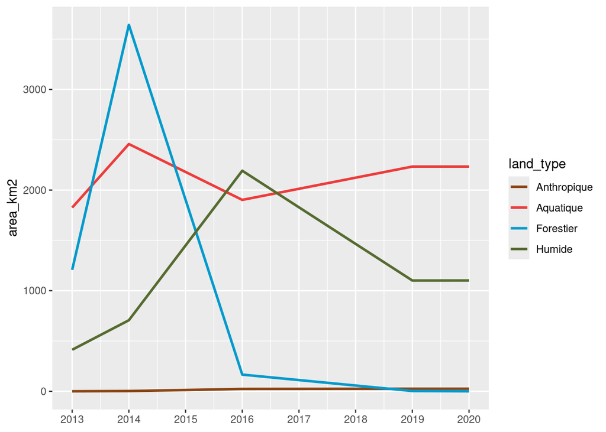

## 4.2 Cartographie de l’occupation des sols des Basses-Terres du Saint-Laurent par Données Québec

### 4.2.1 Description

Ce jeu de données représente l’état des milieux naturels en 2014 ou à une date plus récente (mise à jour le 26 juin 2023) et a été produit dans le cadre du Plan d’action Saint-Laurent pour l’élaboration d’un plan intégré de conservation des milieux naturels et de la biodiversité. L’unité minimale des polygones utilisés est de 0.5 ha. La base de données représente le fruit de l’agrégation et du traitement (dont de la photo-interprétation) de données issues de plusieurs sources : base de données des cultures assurées (Financière agricole du Québec), base de données topographiques du Québec, cadre de référence hydrographique du Québec (MDDELCC), cartographie des cultures au Canada (Agriculture et Agroalimentaire Canada), cartographie détaillée des milieux humides (CIC et MDDELCC), réseau hydrographique national (Ressources naturelles Canada), système d’information écoforestière (MRNF) et système de référence linéaire (Transport Québec).

| Spécifications | Temporelle | Spatiale |
| --- | --- | --- |
| Couverture | 2014 | Basses-Terres du Saint-Laurent |
| Résolution | ponctuelle | - |

### 4.2.2 Limitations

Ne couvre que les basses-terres du Saint-Laurent et n’est représentatif que pour 2014

## 4.3 Utilisation des terres par Agriculture et Agroalimentaire Canada

### 4.3.1 Description

Les données d’utilisation des terres sont des données cartographiques de haute précision et de haute résolution fournies par Agriculture et Agroalimentaire Canada. Ces données sont divisées en 7 classes principales : forêts, lieux habités, terres cultivées, prairies, terres humides, eaux et autres terres. Ces classes sont définies suivant le protocole du Groupe d’experts intergouvernemental sur l’évolution du climat (GIEC). Chacune des classes du GIEC possèdent d’une à 11 sous-classes. Une spécification complète du contenu des données est accessible au lien suivant [AAC, 2018]. Les données sont divisées par zone UTM et projetées en WGS84.

| Spécifications | Temporelle | Spatiale |
| --- | --- | --- |
| Couverture | 2000-2020 | Canada < 60e parallèle |
| Résolution | 5 ans | 30m |

### 4.3.2 Traitement des catégories

| cat | use | class |
| --- | --- | --- |
| Settlement | oui | Anthropique |
| High Reflectance Settlement | oui | Anthropique |
| Settlement Forest | oui | Anthropique |
| Roads | oui | Anthropique |
| Vegetated Settlement | oui | Anthropique |
| Very High Reflectance Settlement | oui | Anthropique |
| Water | oui | Aquatique |
| Forest | oui | Forestier |
| Forest Wetland | oui | Forestier |
| Forest Regenerating after Harvest <20 years | oui | Forestier |
| Forest Wetland Regenerating after Harvest <20 years | oui | Forestier |
| Forest Regenerating after Fire <20 years | oui | Forestier |
| Cropland | oui | Agricole |
| Grassland Unmanaged | non | Grassland |
| Wetland | oui | Humide |
| Other Land | non | Other Land |
| Forest Regenerating after Harvest 20-29 years | non | - |
| Forest Wetland Regenerating after Harvest 20-29 years | non | - |
| Land Converted to Cropland | non | - |
| Newly-Detected Settlement <10 years | non | - |
| Newly-Detected High Reflectance Settlement <10 years | non | - |
| Newly-Detected Settlement Forest <10 years | non | - |
| Newly-Detected Road <10 years | non | - |
| Newly-Detected Vegetated Settlement <10 years | non | - |
| Newly-Detected Very High Reflectance Settlement <10 years | non | - |
| Annual Cropland | non | - |
| Land Converted to Annual Cropland | non | - |
| Snow and Ice | non | - |

### 4.3.3 Visualisation

#### 4.3.3.1 Valeurs brutes

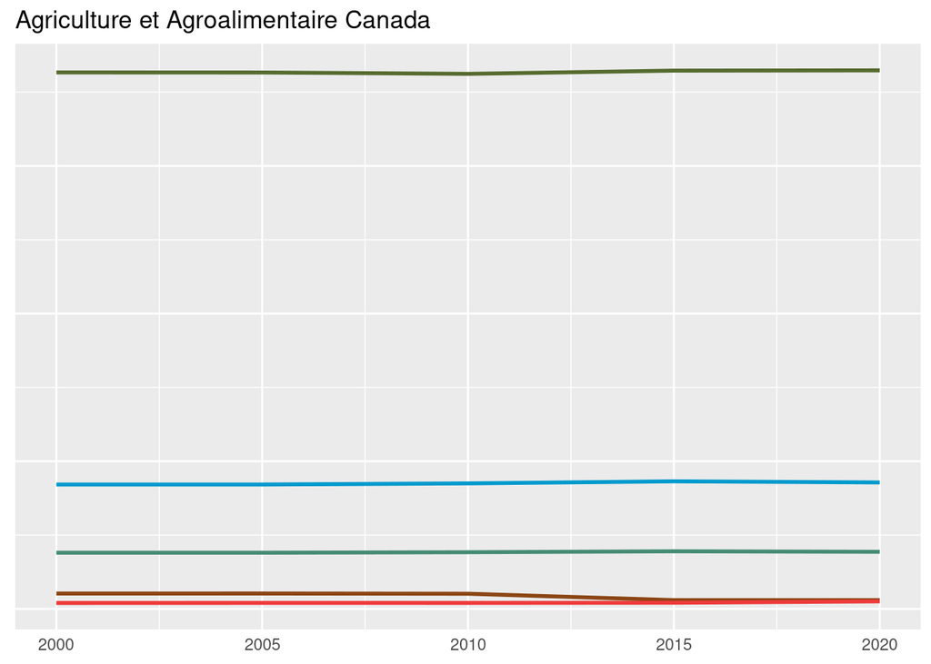

#### 4.3.3.2 Valeurs relatives

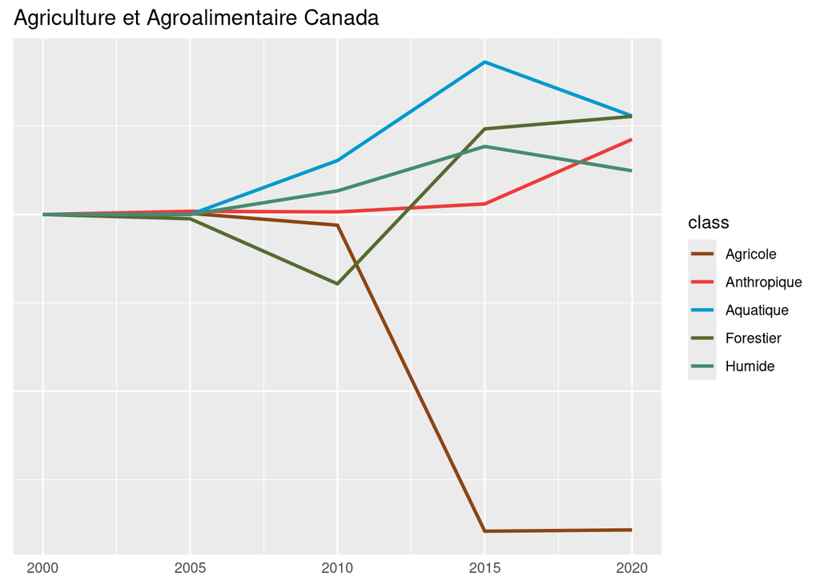

## 4.4 Couverture terrestre par Centre Canadien de Télédétection

### 4.4.1 Description

Ce jeu de données, à l’échelle du Canada, est produit à partir des observations des capteurs Landsat Operational Land Imager, avec une exactitude de 86.9% sans disparité spatiale marquée.

| Spécifications | Temporelle | Spatiale |
| --- | --- | --- |
| Couverture | 2010-2020 | Canada, Etats-Unis & Mexique |
| Résolution | 5 ans | 30m |

### 4.4.2 Traitement des catégories

| pixel_id | class | use | category |
| --- | --- | --- | --- |
| 1 | Forêt de conifères tempérée ou subpolaire | oui | forest |
| 2 | Forêt de conifères (taiga) ou subpolaire | oui | forest |
| 5 | Forêt feuillue tempérée ou subpolaire | oui | forest |
| 6 | Forêt mixte | oui | forest |
| 8 | Arbustaie tempérée ou subpolaire | non | shrubland |
| 10 | Prairie tempérée ou subpolaire | non | grassland |
| 11 | Arbustaie à lichens et à mousses polaire ou subpolaire | non | shrubland |
| 12 | Prairie à lichens et à mousses polaire ou subpolaire | non | grassland |
| 13 | Lande à lichens et à mousses polaire ou subpolaire | non | moorland |
| 14 | Terre humide | oui | wetland |
| 15 | Terre agricole | oui | cropland |
| 16 | Terre stérile | non | barren_land |
| 17 | Milieu urbain | oui | urban |
| 18 | Eau | oui | water |
| 19 | Neige et glace | non | snow_ice |

### 4.4.3 Visualisation

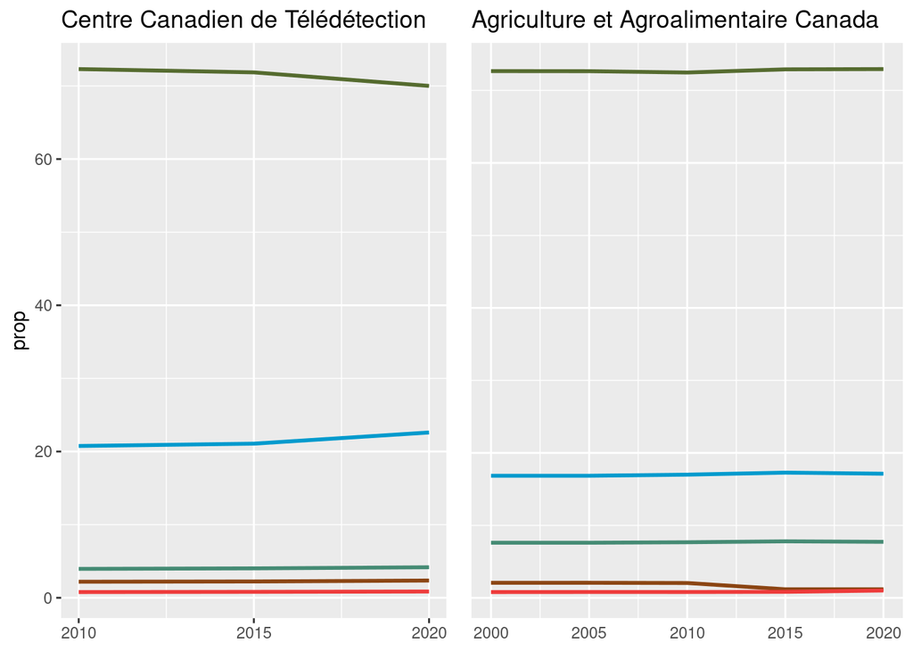

# 5 Évolution de la proportion par catégories naturel vs. artificiel

## 5.1 Données ESA-land cover